# Assignment6

## Assignment6: Logistic Regression

As is typical, the deliverable for this work is a rendered HTML file. Please comment out any extraneous summary and structure commands so as to not clutter up your knitted document.

Begin by reading-in the “PimaIndiansDiabetes2” dataset from the “mlbench” package using the code below.

This will create a data frame named “PimaIndiansDiabetes2”. The response variable in this dataset is the variable “diabetes” that indicates whether the individual in the dataset tests negative (“neg”) or positive (“pos”) for diabetes.

```r
data(PimaIndiansDiabetes2)
PID = PimaIndiansDiabetes2
```

See this link for a description of the variables: https://www.rdocumentation.org/packages/mlbench/versions/2.1-1/topics/PimaIndiansDiabetes.

**Task 1** Examine the structure and summary of the dataset. Are there any variables that need factor conversion or recoding?

- No in this case all of the variables are in good shape.

```r
#str(PID)
#summary(PID)
```

**Task 2** As we did with the Titanic dataset, use vim_plot to visualize missing data in this dataset. Comment on the missingness and potential strategies for dealing with the missing data.

- It can be seen that over 40% of the insulin variable is missing, and around 30% of the triceps are missing. In this case I would recommend imputation as removing the entire variable or all of the observations would severely limit our data set. For the other variables that are only missing a few we could delete them entirely. Though one thing to consider is that fact that this is a medical data set and using imputation could create false data which would be bad considering how it involves human lives. It would need to be decided if the data is important enough to just do row deletion to keep accuracy or if we can use imputation.

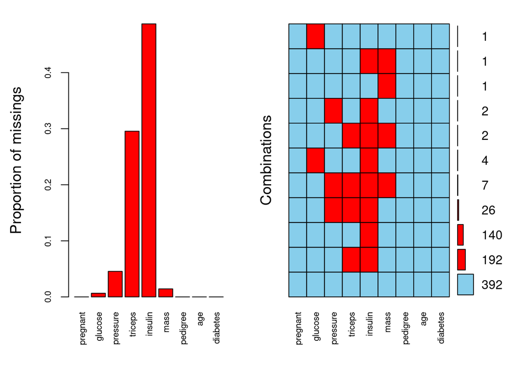

```r
vim_plot = aggr(PID, numbers = TRUE, prop = c(TRUE, FALSE),cex.axis=.7)
```

**Task 3** Remove the “insulin” column and then perform row-wise deletion for missingness. Order is important here. Make sure you remove the column first before row-wise deletion.

```r
PID = PID %>% dplyr::select(-insulin)
```

```r
PID = PID %>% drop_na()
```

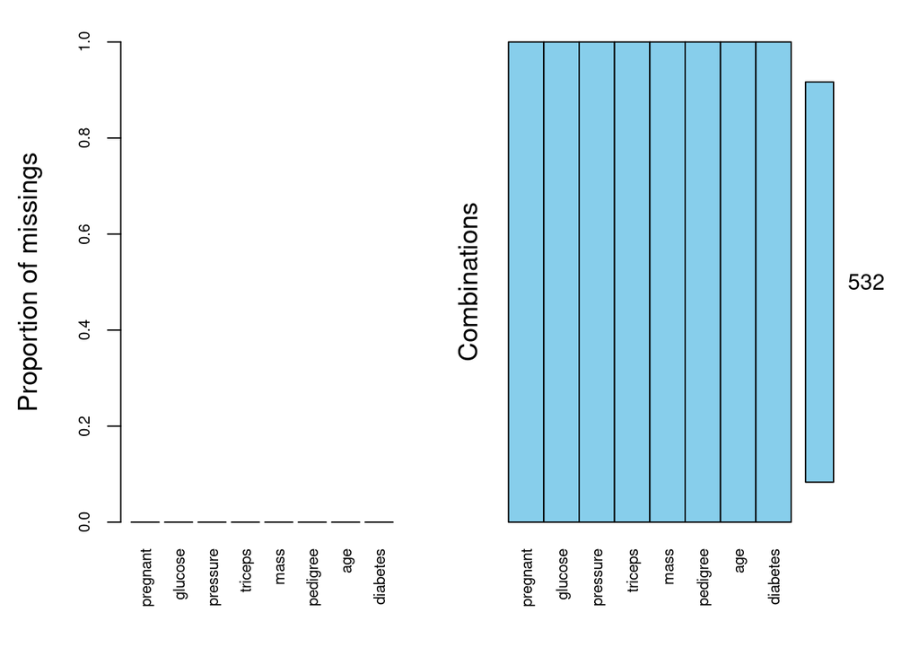

```r
vim_plot = aggr(PID, numbers = TRUE, prop = c(TRUE, FALSE),cex.axis=.7)
```

**Task 4** Split the dataset into training and testing sets. Put 70% of the data in the training set. Use a random number seed of 1234. Note that the response variable is “diabetes”.

```r
set.seed(1234)
PID_split = initial_split(PID, prop = 0.7, strata = diabetes)
train = training(PID_split)
test = testing(PID_split)
```

**Task 5** Using the training set, create appropriate charts to visualize the relationship between each variable and the “diabetes” variable. Comment on each relationship.

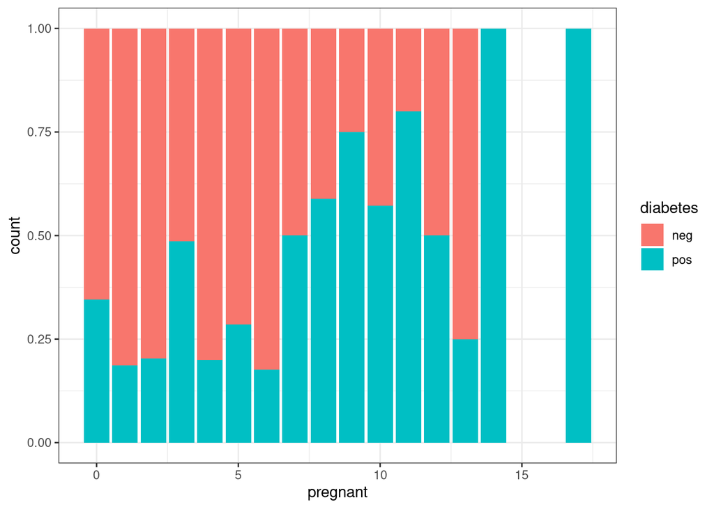

```r
ggplot(train,aes(x=pregnant,fill=diabetes)) + geom_bar(position = "fill") + theme_bw()
```

- we can see that as you are pregnant more times the more likely you are to have diabetes.

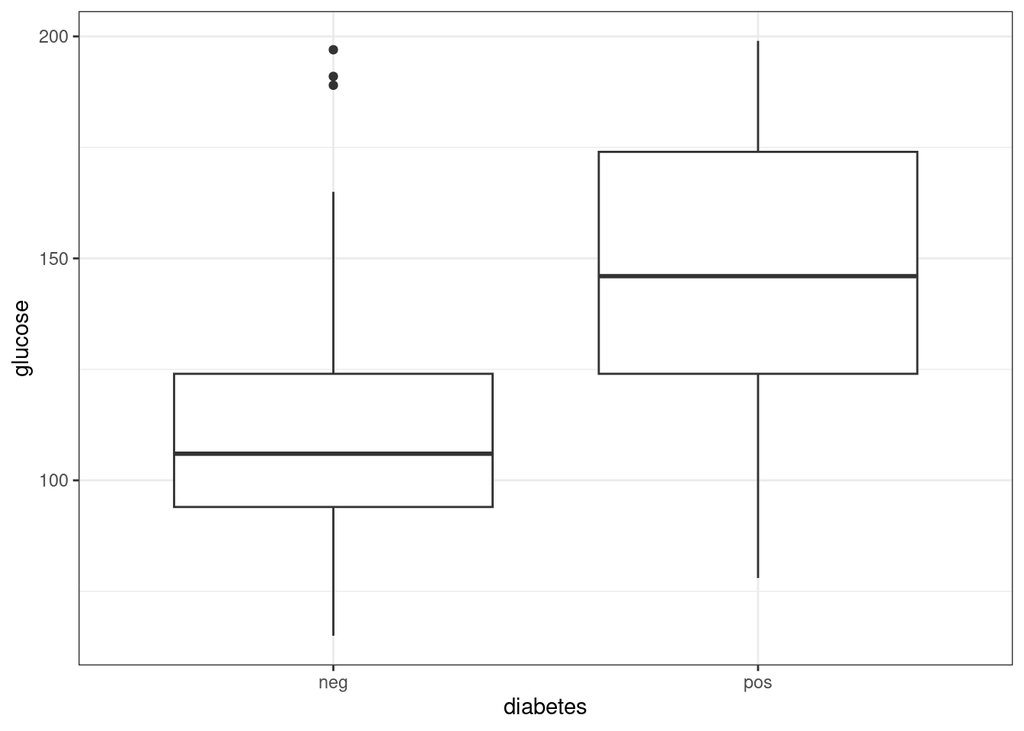

```r
ggplot(train,aes(x=diabetes, y=glucose)) + geom_boxplot() + theme_bw()
```

- Here it is a pretty big difference between glucose levels for diabetics and non-diabetics. The higher the glucose level is the more likely they will be diabetic.

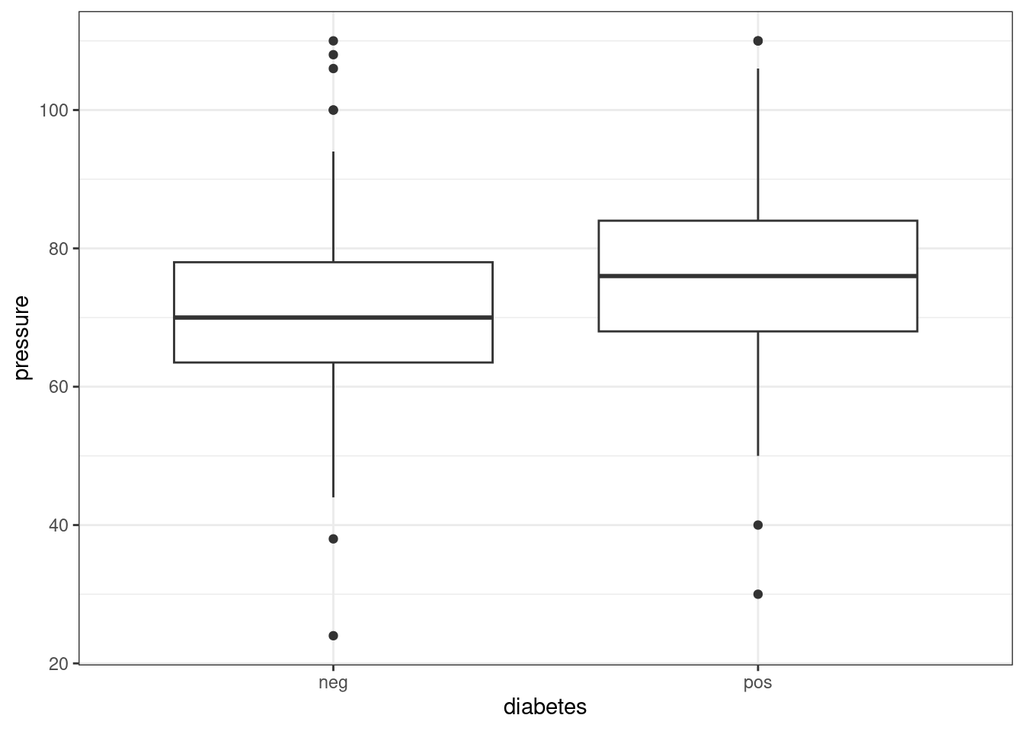

```r
ggplot(train,aes(x=diabetes, y=pressure)) + geom_boxplot() + theme_bw()
```

- While there is a slight difference it is only about 7 points off between diabetics and non-diabetics though blood pressure does increase if you have diabetes.

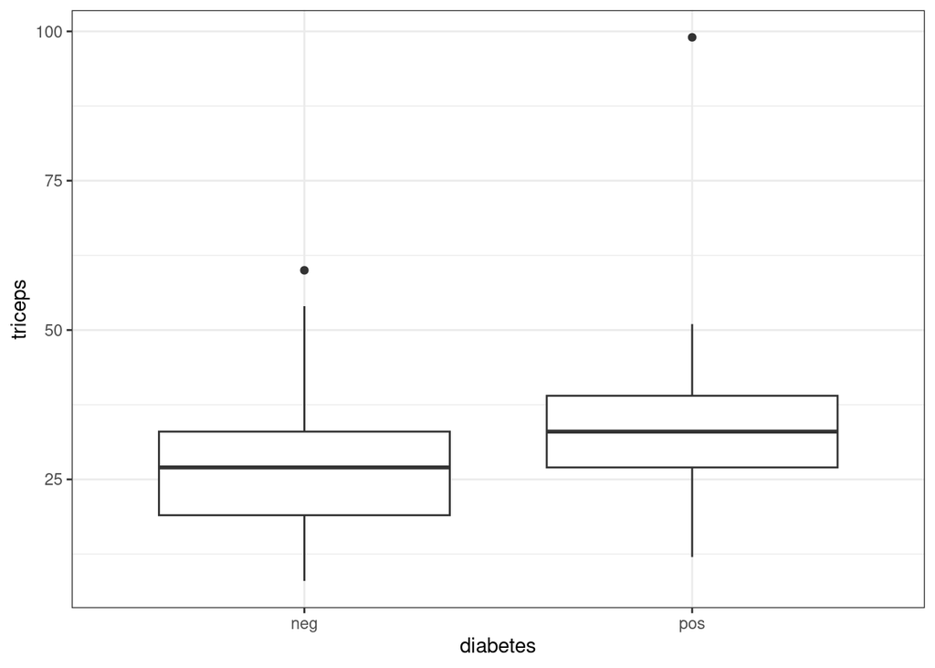

```r
ggplot(train,aes(x=diabetes, y=triceps)) + geom_boxplot() + theme_bw()
```

- While there is not much of a difference there are higher tricep levels in diabetics which means they have thicker skin.

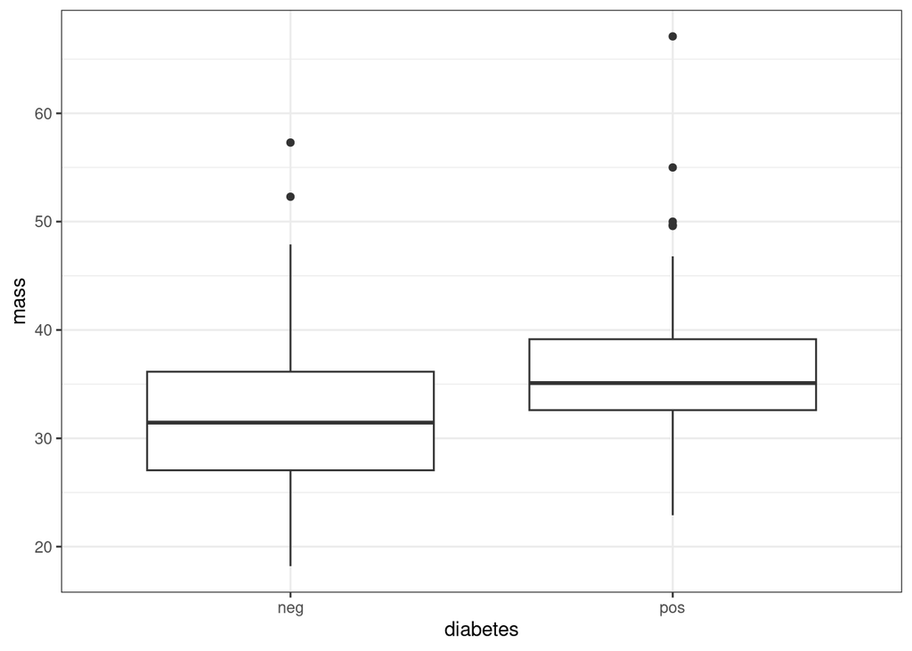

```r
ggplot(train,aes(x=diabetes, y=mass)) + geom_boxplot() + theme_bw()
```

- There is a decent difference in BMI for diabetics and non-diabetics with the diabetics having a much higher BMI.

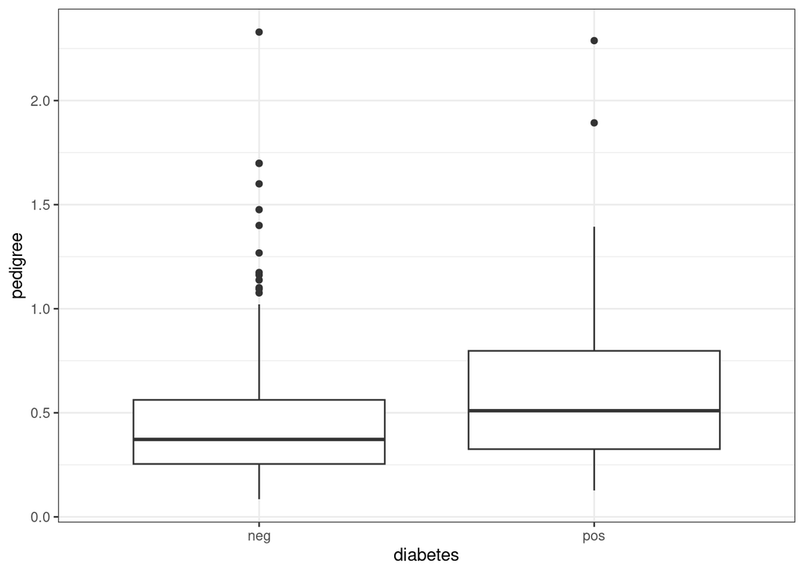

```r
ggplot(train,aes(x=diabetes, y=pedigree)) + geom_boxplot() + theme_bw()
```

- There is a difference considering pedigree as type 1 is genetic.

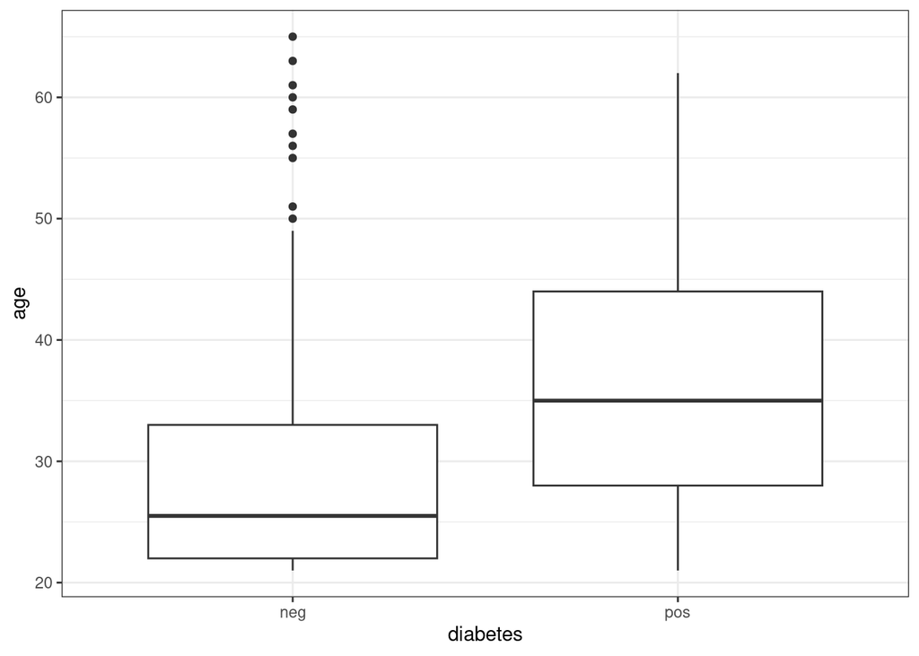

```r
ggplot(train,aes(x=diabetes, y=age)) + geom_boxplot() + theme_bw()
```

- Age has a huge difference between positive and negative with positive being much higher. About a 10-12 year gap.

**Task 6** Create a logistic regression model (on the training set) using “glucose” to predict “diabetes”. Comment on the model quality. Use the Tidymodels framework.

```r
logreg_model =
  logistic_reg() %>%
  set_engine("glm")

logreg_recipe = recipe(diabetes ~ glucose , data = train) %>%
               step_dummy(all_nominal(), -all_outcomes())

logreg_wf = workflow() %>%
  add_recipe(logreg_recipe) %>%
  add_model(logreg_model)

logreg_fit = fit(logreg_wf,train)
```

```r
options(scipen = 999)
tidy(logreg_fit)
```

```
# A tibble: 2 × 5
  term        estimate std.error statistic  p.value
  <chr>          <dbl>     <dbl>     <dbl>    <dbl>
1 (Intercept)  -6.61     0.676       -9.78 1.39e-22
2 glucose       0.0467   0.00517      9.04 1.61e-19
```

```r
glance(logreg_fit)
```

```
# A tibble: 1 × 8
  null.deviance df.null logLik   AIC   BIC deviance df.residual  nobs
          <dbl>   <int>  <dbl> <dbl> <dbl>    <dbl>       <int> <int>
1          471.     370  -174.  352.  360.     348.         369   371
```

**Task 7** Create the best model that you can to predict “diabetes”. Comment on the model quality.

```r
logreg_model2 =
  logistic_reg() %>%
  set_engine("glm")

logreg_recipe2 = recipe(diabetes ~ glucose+age+triceps , data = train) %>%
               step_dummy(all_nominal(), -all_outcomes())

logreg_wf2 = workflow() %>%
  add_recipe(logreg_recipe2) %>%
  add_model(logreg_model2)

logreg_fit2 = fit(logreg_wf2,train)
```

```r
options(scipen = 999)
tidy(logreg_fit2)
```

```
# A tibble: 4 × 5
  term        estimate std.error statistic  p.value
  <chr>          <dbl>     <dbl>     <dbl>    <dbl>
1 (Intercept)  -8.78     0.898       -9.78 1.43e-22
2 glucose       0.0417   0.00526      7.91 2.52e-15
3 age           0.0507   0.0136       3.74 1.86e- 4
4 triceps       0.0378   0.0143       2.65 8.15e- 3
```

```r
glance(logreg_fit2)
```

```
# A tibble: 1 × 8
  null.deviance df.null logLik   AIC   BIC deviance df.residual  nobs
          <dbl>   <int>  <dbl> <dbl> <dbl>    <dbl>       <int> <int>
1          471.     370  -162.  332.  348.     324.         367   371
```

```r
predicttrain = predict(logreg_fit2, train, type="prob")
head(predicttrain)
```

```
# A tibble: 6 × 2
  .pred_neg .pred_pos
      <dbl>     <dbl>
1     0.648    0.352
2     0.955    0.0451
3     0.295    0.705
4     0.553    0.447
5     0.827    0.173
6     0.777    0.223
```

```r
predicttrain = predicttrain[2]
head(predicttrain)
```

```
# A tibble: 6 × 1
  .pred_pos
      <dbl>
1    0.352
2    0.0451
3    0.705
4    0.447
5    0.173
6    0.223
```

```r
newdata = data.frame(glucose = 145, age=65, triceps = 30 )
predict(logreg_fit2, newdata, type="prob")
```

```
# A tibble: 1 × 2
  .pred_neg .pred_pos
      <dbl>     <dbl>
1     0.155     0.845
```

```r
logreg2_output = tidy(logreg_fit2)
logreg2_output = logreg2_output %>% select(term, estimate, p.value)
logreg2_output
```

```
# A tibble: 4 × 3
  term        estimate  p.value
  <chr>          <dbl>    <dbl>
1 (Intercept)  -8.78   1.43e-22
2 glucose       0.0417 2.52e-15
3 age           0.0507 1.86e- 4
4 triceps       0.0378 8.15e- 3
```

- From the different tests i ran I can see that the best model contains age, triceps, and glucose. The p-value for each variable is below 5% and the AIC is 332 which is a decrease from our earlier models. Overall I feel as if this is a pretty good model.